# Data Visualization

1. **Univariate data visualization**

   ```
   - bar charts : sns.countplot()
    - bar charts absolute vs relative frequency : sns.barplot()
    - pie charts : plt.pie()
    - Histograms : plt.hist() , sns.distplot()
   ```

2. **Bivariate data visualization**

   ```
   - Scatter plots : plt.scatter() , sns.regplot()
    - Heat maps : plt.hist2d()
    - Violin plots : sns.violinplot()
    - Box plots : sns.boxplot()
    - clustered bar charts : sns.heatmap() , sns.countplot(hue = 'column_name')
    - Faceting : g = sns.FacetGrid() , g.map()
    - Adaptation of univariate plots: sns.barplot() , sns.pointplot()
    - Line plots : plt.errorbar()
    - Swarm plots : sns.swarmplot()
    - Rug plots : sns.rugplot()
    - Strip plot : sns.stripplot()
   ```

3. **Multivariate data visualization**

   ```
   - Non positional encodings for third variable
    - Color palettes
    - Faceting in two directions
    - other adaptations of bivariate plots
    - plot matrices
   ```

4. **Feature Engineering**

# Data Visualisation : Univariate

```python
import numpy as np
import pandas as pd
import matplotlib.pyplot as plt
import seaborn as sns

%matplotlib inline
```

```python
df = pd.read_csv('pokemon.csv')
print(df.shape)
df.head()
```

```
(807, 14)
```

|  | id | species | generation_id | height | weight | base_experience | type_1 | type_2 | hp | attack | defense | speed | special-attack | special-defense |
| --- | --- | --- | --- | --- | --- | --- | --- | --- | --- | --- | --- | --- | --- | --- |
| 0 | 1 | bulbasaur | 1 | 0.7 | 6.9 | 64 | grass | poison | 45 | 49 | 49 | 45 | 65 | 65 |
| 1 | 2 | ivysaur | 1 | 1.0 | 13.0 | 142 | grass | poison | 60 | 62 | 63 | 60 | 80 | 80 |
| 2 | 3 | venusaur | 1 | 2.0 | 100.0 | 236 | grass | poison | 80 | 82 | 83 | 80 | 100 | 100 |
| 3 | 4 | charmander | 1 | 0.6 | 8.5 | 62 | fire | NaN | 39 | 52 | 43 | 65 | 60 | 50 |
| 4 | 5 | charmeleon | 1 | 1.1 | 19.0 | 142 | fire | NaN | 58 | 64 | 58 | 80 | 80 | 65 |

## Bar charts : sns.countplot( )

Let's create a bar chart on of categorical variable in the dataset generation_id. Even the values in the columns look numeric they're actually just categorical labels indicating when each species was introduced to the series from first to seventh generation.

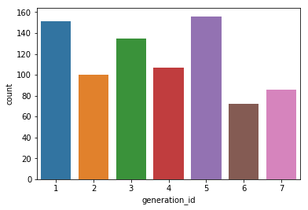

```python
sns.countplot(data = df, x ='generation_id');
```

> One thing that bothers about the default settings is that each bar is illustrated with different color.

```python
sns.color_palette()
```

```
[(0.12156862745098039, 0.4666666666666667, 0.7058823529411765),
 (1.0, 0.4980392156862745, 0.054901960784313725),
 (0.17254901960784313, 0.6274509803921569, 0.17254901960784313),
 (0.8392156862745098, 0.15294117647058825, 0.1568627450980392),
 (0.5803921568627451, 0.403921568627451, 0.7411764705882353),
 (0.5490196078431373, 0.33725490196078434, 0.29411764705882354),
 (0.8901960784313725, 0.4666666666666667, 0.7607843137254902),
 (0.4980392156862745, 0.4980392156862745, 0.4980392156862745),
 (0.7372549019607844, 0.7411764705882353, 0.13333333333333333),
 (0.09019607843137255, 0.7450980392156863, 0.8117647058823529)]
```

> This function returns a list of tuples corresponding to the color palette set in the function's arguments. and i am selecting one from it.

```python
base_color = sns.color_palette()[0]
```

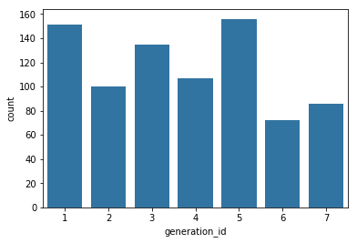

```python
sns.countplot(data = df, x='generation_id', color = base_color);
```

> We can set the order of the variables using order parameter. Now i am using explicit or hard core values entry.

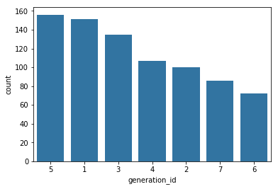

```python
sns.countplot(data = df, x='generation_id', color = base_color, order = [5,1,3,4,2,7,6]);
```

```python
df.generation_id.value_counts()
```

```
5    156
1    151
3    135
4    107
2    100
7     86
6     72
Name: generation_id, dtype: int64
```

> This can be done programatically as below

```python
gen_order = df.generation_id.value_counts().index
gen_order
```

```
Int64Index([5, 1, 3, 4, 2, 7, 6], dtype='int64')
```

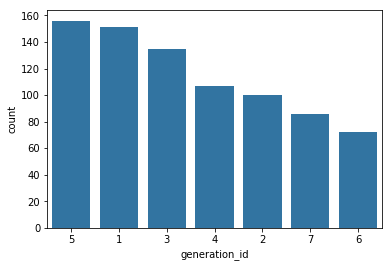

```python
sns.countplot(data = df, x='generation_id', color = base_color, order = gen_order);
```

Let's create a bar chart for another categorical variable.

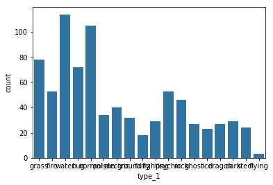

```python
sns.countplot(data = df,x='type_1',color=base_color);
```

We can see that the x labels are overlapping. Hence we can use plt.xticks() functions of matplotlib and set the rotation parameter to 90, to rotate the labels by 90 degrees.

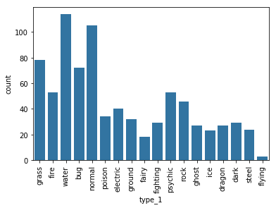

```python
sns.countplot(data = df,x='type_1',color=base_color);
plt.xticks(rotation = 90);
```

We can simply create a horizontal bar chart by using parameter y instead of x in countplot function

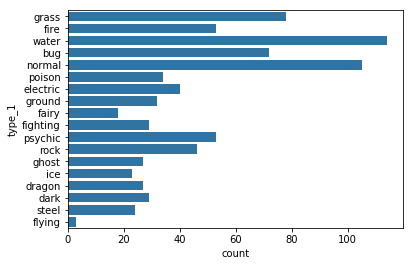

```python
sns.countplot(data = df,y='type_1',color=base_color);
```

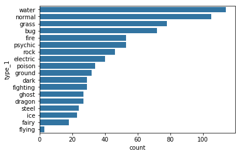

```python
type_order = df.type_1.value_counts().index
sns.countplot(data=df,y='type_1',color=base_color,order=type_order);
```

## Absolute vs Relative frequency

By default, seaborn's countplot function will summarize and plot the data in terms of absolute frequency, or pure counts. In certain cases, you might want to understand the distribution of data or want to compare levels in terms of proportions of the whole. In this case, you will want to plot the data in terms of relative frequency, where the height indicates the proportion of data taking each level, rather than the absolute count.

```python
pokemon = df.melt(id_vars = ['id','species'],
                 value_vars = ['type_1','type_2'],
                 var_name = 'type_level', value_name = 'type').dropna()
```

```python
pokemon.head()
```

|  | id | species | type_level | type |
| --- | --- | --- | --- | --- |
| 0 | 1 | bulbasaur | type_1 | grass |
| 1 | 2 | ivysaur | type_1 | grass |
| 2 | 3 | venusaur | type_1 | grass |
| 3 | 4 | charmander | type_1 | fire |
| 4 | 5 | charmeleon | type_1 | fire |

```python
type_counts = pokemon.type.value_counts()
type_order = type_counts.index
type_counts
```

```
water       131
normal      109
flying       98
grass        97
psychic      82
bug          77
poison       66
fire         64
ground       64
rock         60
fighting     54
electric     48
steel        47
fairy        47
dark         46
dragon       45
ghost        43
ice          34
Name: type, dtype: int64
```

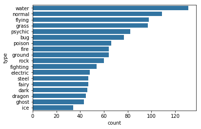

```python
sns.countplot(data = pokemon, y='type',color=base_color,order=type_order);
```

```python
n_pokemon = df.shape[0]
max_type_count = type_counts[0]
max_prop = max_type_count/ n_pokemon
max_prop
```

```
0.1623296158612144
```

```python
tick_props = np.arange(0,max_prop,0.02)
tick_props
```

```
array([0.  , 0.02, 0.04, 0.06, 0.08, 0.1 , 0.12, 0.14, 0.16])
```

```python
tick_names = ['{:0.2f}'.format(v) for v in tick_props]
tick_names
```

```
['0.00', '0.02', '0.04', '0.06', '0.08', '0.10', '0.12', '0.14', '0.16']
```

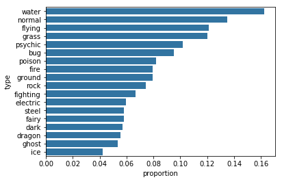

```python
sns.countplot(data = pokemon, y='type',color=base_color,order=type_order);
plt.xticks(tick_props*n_pokemon, tick_names)
plt.xlabel('proportion');
```

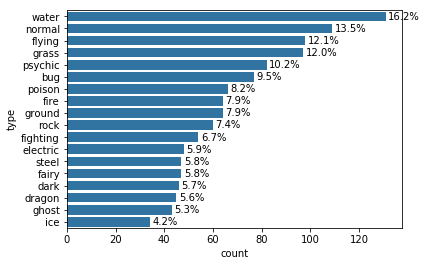

```python
sns.countplot(data = pokemon, y='type',color=base_color,order=type_order);

for i in range(type_counts.shape[0]):
    count = type_counts[i]
    percent = '{:0.1f}%'.format(100*count/n_pokemon)
    plt.text(count+1,i,percent, va='center')
```

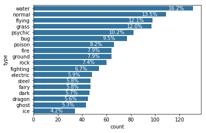

```python
sns.countplot(data = pokemon, y='type',color=base_color,order=type_order);

for i in range(type_counts.shape[0]):
    count = type_counts[i]
    percent = '{:0.1f}%'.format(100*count/n_pokemon)
    plt.text(count-20,i,percent, va='center',color='white')
```

```python
na_counts = df.isna().sum()
na_counts
```

```
id                   0
species              0
generation_id        0
height               0
weight               0
base_experience      0
type_1               0
type_2             402
hp                   0
attack               0
defense              0
speed                0
special-attack       0
special-defense      0
dtype: int64
```

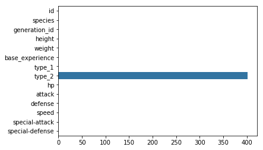

```python
sns.barplot(na_counts,na_counts.index.values,color=base_color);
```

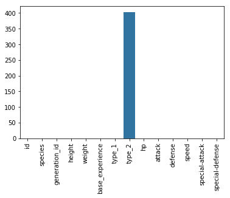

```python
sns.barplot(na_counts.index.values,na_counts,color=base_color);
plt.xticks(rotation=90);
```

We could treat the variable names as levels of a categorical variable, and create a resulting bar plot. However, since the data is not in its tidy, unsummarized form, we need to make use of a different plotting function. Seaborn's barplot function is built to depict a summary of one quantitative variable against levels of a second, qualitative variable, but can be used here.

## Pie Charts : plt.pie( )

You can create a pie chart with matplotlib's **`pie function`**. This function requires that the data be in a summarized form: the primary argument to the function will be the wedge sizes.

```
# code for the pie chart seen below
sorted_counts = df['cat_var'].value_counts()
plt.pie(sorted_counts, labels = sorted_counts.index, startangle = 90,
        counterclock = False);
plt.axis('square')
```

[figure not shown]

The axis function call and 'square' argument makes it so that the scaling of the plot is equal on both the x- and y-axes. Without this call, the pie could end up looking oval-shaped, rather than a circle.

## Donut Plot

A sister plot to the pie chart is the donut plot

It's just like a pie chart, except that there's a hole in the center of the plot. Perceptually, there's not much difference between a donut plot and a pie chart, and donut plots should be used with the same guidelines as a pie chart. Aesthetics might be one of the reasons why you would choose one or the other. For instance, you might see statistics reported in the hole of a donut plot to better make use of available space.

To create a donut plot, you can add a "wedgeprops" argument to the pie function call. By default, the radius of the pie (circle) is 1; setting the wedges' width property to less than 1 removes coloring from the center of the circle.

```
sorted_counts = df['cat_var'].value_counts()
plt.pie(sorted_counts, labels = sorted_counts.index, startangle = 90,
        counterclock = False, wedgeprops = {'width' : 0.4});
plt.axis('square')
```

[figure not shown]

## Histograms

histogram on a quantitative variable. Lets create it on speed

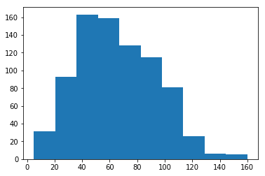

```python
plt.hist(data=df, x='speed');
```

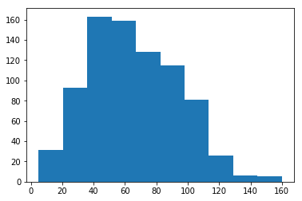

```python
plt.hist(df.speed);
```

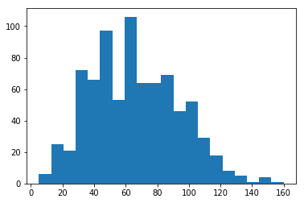

```python
plt.hist(data=df, x='speed',bins=20)
```

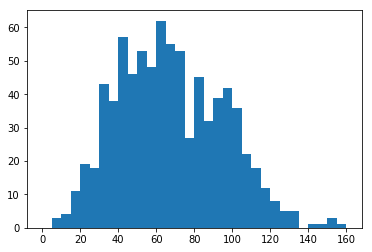

```python
bins = np.arange(0,df.speed.max()+5,5)
plt.hist(df.speed,bins=bins);
```

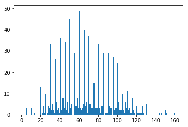

```python
bins = np.arange(0,df.speed.max()+1,1)
plt.hist(df.speed,bins=bins);
```

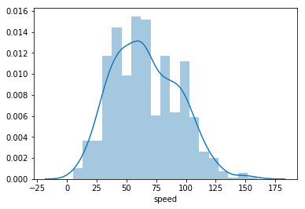

```python
sns.distplot(df.speed);
```

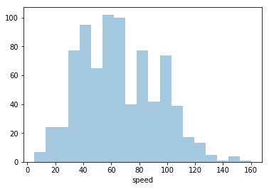

```python
sns.distplot(df.speed,kde=False);
```

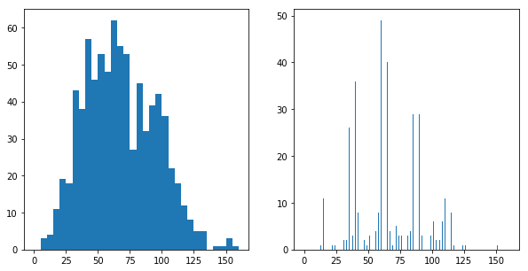

```python
plt.figure(figsize = [10, 5]) # larger figure size for subplots

# example of somewhat too-large bin size
plt.subplot(1, 2, 1) # 1 row, 2 cols, subplot 1
bin_edges = np.arange(0, df['speed'].max()+5, 5)
plt.hist(data = df, x = 'speed', bins = bin_edges)

# example of somewhat too-small bin size
plt.subplot(1, 2, 2) # 1 row, 2 cols, subplot 2
bin_edges = np.arange(0, df['speed'].max()+1/4, 1/4)
plt.hist(data = df, x = 'speed', bins = bin_edges);
```

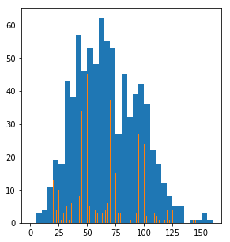

```python
plt.figure(figsize = [10, 5]) # larger figure size for subplots

# example of somewhat too-large bin size
plt.subplot(1, 2, 1) # 1 row, 2 cols, subplot 1
bin_edges = np.arange(0, df['speed'].max()+5, 5)
plt.hist(data = df, x = 'speed', bins = bin_edges)

# example of somewhat too-small bin size
#plt.subplot(1, 2, 2) # 1 row, 2 cols, subplot 2
bin_edges = np.arange(0, df['speed'].max()+1/4, 1/4)
plt.hist(data = df, x = 'speed', bins = bin_edges);
```

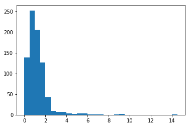

```python
bins = np.arange(0,df.height.max()+0.5,0.5)
plt.hist(df.height,bins=bins);
```

Fairly right skewed. change the axis limits using plt.xlim()

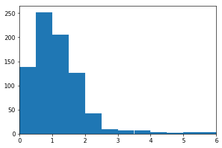

```python
bins = np.arange(0,df.height.max()+0.5,0.5)
plt.hist(df.height,bins=bins);
plt.xlim((0,6));
```

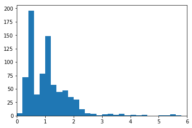

```python
bins = np.arange(0,df.height.max()+0.2,0.2)
plt.hist(df.height,bins=bins);
plt.xlim((0,6));
```

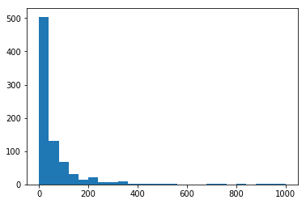

```python
bins = np.arange(0,df['weight'].max()+40,40)
plt.hist(df.weight,bins=bins);
```

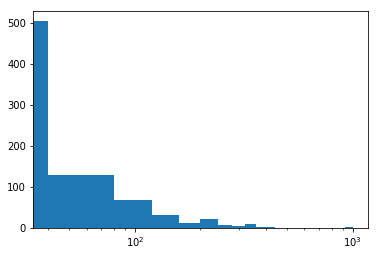

```python
bins = np.arange(0,df['weight'].max()+40,40)
plt.hist(df.weight,bins=bins);
plt.xscale('log');
```

```python
df.weight.describe()
```

```
count    807.000000
mean      61.771128
std      111.519355
min        0.100000
25%        9.000000
50%       27.000000
75%       63.000000
max      999.900000
Name: weight, dtype: float64
```

```python
np.log10(df.weight.describe())
```

```
count    2.906874
mean     1.790786
std      2.047350
min     -1.000000
25%      0.954243
50%      1.431364
75%      1.799341
max      2.999957
Name: weight, dtype: float64
```

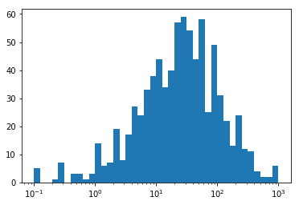

```python
bins = 10** np.arange(-1,3+0.1,0.1)
plt.hist(df.weight,bins=bins)
plt.xscale('log')
```

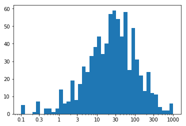

```python
bins = 10** np.arange(-1,3+0.1,0.1)
ticks = [0.1,0.3,1,3,10,30,100,300,1000]
labels = ['{}'.format(v) for v in ticks]
plt.hist(df.weight,bins=bins)
plt.xscale('log')
plt.xticks(ticks,labels);
```